# Batch effect management

Eva

28 June 2026

# Introduction

Batch effects refer to unwanted variation in measured data arising from biological, technical or computational factors that are not the primary focus of the study and that may obscure the biological effects of interest (e.g., treatment effects). Handling batch effects is a necessary step to improve the reproducibility of research studies. However, methods developed for batch effects often rely on strong assumptions about data characteristics and the types of batch effects.

This hands-on practice provides guidelines for batch effect detection, management, and evaluation of method effectiveness through visual and numerical approaches. Although the practice will illustrate the workflow using microbiome data, the concepts and techniques presented are broadly applicable to any type of omics data.

## Case study description

**Anaerobic Digestion** This study explored microbial indicators that could improve the efficacy of the Anaerobic Digestion (AD) bioprocess and prevent its failure (Chapleur et al. 2016). Samples were treated with two different ranges of phenol concentrations (effect of interest) and processed on five different dates (batch effect). This study exhibits a clear and strong batch effect with an approx. balanced batch x treatment design.

## Packages installation and loading

First, let’s load the packages necessary for the analysis, and check the version of each package.

**Note**: There is currently an issue with downloading *PLSDAbatch* from Bioconductor. Please try installing it directly from GitHub instead, and make sure that the installed version is later than 2.0.0.

```r
# CRAN
cran.pkgs <- c('pheatmap', 'vegan', 'ruv', 'ggplot2',
               'performance', 'gridExtra', 'see')

# install.packages(cran.pkgs)

# Bioconductor
bioc.pkgs <- c('mixOmics', 'sva', 'limma', 'Biobase', 'metagenomeSeq',
               'PLSDAbatch')

# if(!require("BiocManager", quietly = TRUE)) install.packages("BiocManager")
# BiocManager::install(bioc.pkgs)
# BiocManager::install("EvaYiwenWang/PLSDAbatch") # install from GitHub

# load packages
suppressMessages(suppressWarnings(sapply(c(cran.pkgs, bioc.pkgs), require,
                                         character.only = TRUE)))
```

```
     pheatmap         vegan           ruv       ggplot2   performance     gridExtra
         TRUE          TRUE          TRUE          TRUE          TRUE          TRUE
          see      mixOmics           sva         limma       Biobase metagenomeSeq
         TRUE          TRUE          TRUE          TRUE          TRUE          TRUE
   PLSDAbatch
         TRUE
```

```r
# print package versions
sapply(c(cran.pkgs, bioc.pkgs), package.version)
```

```
     pheatmap         vegan           ruv       ggplot2   performance     gridExtra
     "1.0.13"       "2.7-5"     "0.9.7.1"       "4.0.3"      "0.17.0"         "2.3"
          see      mixOmics           sva         limma       Biobase metagenomeSeq
     "0.14.0"      "6.32.0"      "3.56.0"      "3.64.3"      "2.68.0"      "1.50.0"
   PLSDAbatch
      "2.1.1"
```

# Load data

Before detecting batch effects, the data should be properly preprocessed. The preprocessing steps may vary depending on the type of omics data.

```r
load(file = './example_ADdata.rda')

ad.clr = example_ADdata$data
ad.trt = example_ADdata$treatment
ad.batch = example_ADdata$batch

dim(ad.clr)
```

```
[1]  75 231
```

The microbial data include 231 OTUs and 75 samples.

#### Exercise 1: How many samples are there within each treatment and batch group?

# Batch effect detection

## Principal component analysis (PCA)

To visualise the data, let’s apply `pca()` function from *mixOmics* package and `Scatter_Density()` function from *PLSDAbatch* to represent the PCA sample plot with densities.

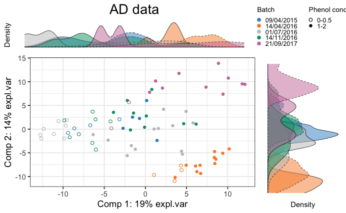

```r
ad.pca.before <- mixOmics::pca(ad.clr, ncomp = 3, scale = TRUE)

Scatter_Density(components = ad.pca.before$variates$X, comp = c(1,2),
                expl.var = ad.pca.before$prop_expl_var$X,
                batch = ad.batch, trt = ad.trt,
                title = 'AD data', trt.legend.title = 'Phenol conc.',
                color.set = color.mixo(1:5))
```

#### Exercise 2: Interpret the PCA plot created above

## Boxplots and density plots

We can also visualise individual variables (OTUs in this case). For example, we can select the top OTU driving the major variation in PCA using `selectVar()` in *mixOmics* package. We can then plot this OTU as boxplots and density plots using `box_plot()` and `density_plot()` in *PLSDAbatch*.

```r
ad.OTU.name <- selectVar(ad.pca.before, comp = 1)$name[1]

ad.OTU_batch <- data.frame(value = ad.clr[,ad.OTU.name], batch = ad.batch)
head(ad.OTU_batch)
```

|  | value | batch |
| --- | --- | --- |
| E1aJ16_A | 2.580663 | 09/04/2015 |
| E5aJ16_A | 2.904407 | 09/04/2015 |
| E6aJ16_A | 1.909571 | 09/04/2015 |
| E6aJ48_A | 1.283897 | 09/04/2015 |
| E7aJ16_A | 1.517973 | 09/04/2015 |
| E7aJ26_A | 1.076104 | 09/04/2015 |

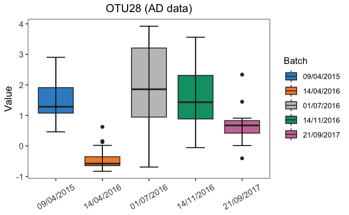

```r
box_plot(df = ad.OTU_batch, title = paste(ad.OTU.name, '(AD data)'),
         x.angle = 30, color.set = color.mixo(1:5))
```

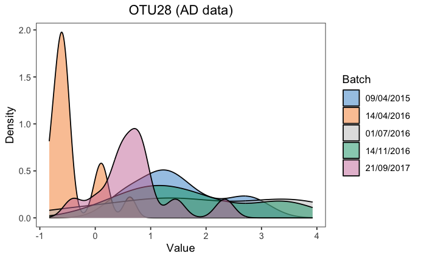

```r
density_plot(df = ad.OTU_batch, title = paste(ad.OTU.name, '(AD data)'), color.set = color.mixo(1:5))
```

The boxplot and density plot indicated a strong date effect because of the differences between “14/04/2016”, “21/09/2017” and the other dates in the “OTU28”.

To assess statistical significance, we can apply a linear regression model to “OTU28” using `linear_regres()` from *PLSDAbatch* with batch and treatment effects as covariates. To compare “14/04/2016” and “21/09/2017” to the other batches, we need to set them as the reference levels, respectively, using `relevel()` from *stats*.

```r
# reference level: 14/04/2016
ad.batch <- relevel(x = ad.batch, ref = '14/04/2016')

ad.OTU.lm <- linear_regres(data = ad.clr[,ad.OTU.name],
                           trt = ad.trt,
                           batch.fix = ad.batch,
                           type = 'linear model')
summary(ad.OTU.lm$model$data)
```

```
Call:
stats::lm(formula = y ~ trt + batch.fix)

Residuals:
    Min      1Q  Median      3Q     Max
-1.9384 -0.3279  0.1635  0.3849  0.9887

Coefficients:
                    Estimate Std. Error t value Pr(>|t|)
(Intercept)           0.8501     0.2196   3.871 0.000243 ***
trt1-2               -1.6871     0.1754  -9.617 2.27e-14 ***
batch.fix09/04/2015   1.5963     0.2950   5.410 8.55e-07 ***
batch.fix01/07/2016   2.0839     0.2345   8.886 4.82e-13 ***
batch.fix14/11/2016   1.7405     0.2480   7.018 1.24e-09 ***
batch.fix21/09/2017   1.2646     0.2690   4.701 1.28e-05 ***
---
Signif. codes:  0 ‘***’ 0.001 ‘**’ 0.01 ‘*’ 0.05 ‘.’ 0.1 ‘ ’ 1

Residual standard error: 0.7033 on 69 degrees of freedom
Multiple R-squared:  0.7546,    Adjusted R-squared:  0.7368
F-statistic: 42.44 on 5 and 69 DF,  p-value: < 2.2e-16
```

```r
# reference level: 21/09/2017
ad.batch <- relevel(x = ad.batch, ref = '21/09/2017')

ad.OTU.lm <- linear_regres(data = ad.clr[,ad.OTU.name],
                           trt = ad.trt,
                           batch.fix = ad.batch,
                           type = 'linear model')
summary(ad.OTU.lm$model$data)
```

```
Call:
stats::lm(formula = y ~ trt + batch.fix)

Residuals:
    Min      1Q  Median      3Q     Max
-1.9384 -0.3279  0.1635  0.3849  0.9887

Coefficients:
                    Estimate Std. Error t value Pr(>|t|)
(Intercept)           2.1147     0.2502   8.453 2.97e-12 ***
trt1-2               -1.6871     0.1754  -9.617 2.27e-14 ***
batch.fix14/04/2016  -1.2646     0.2690  -4.701 1.28e-05 ***
batch.fix09/04/2015   0.3317     0.3139   1.056  0.29446
batch.fix01/07/2016   0.8193     0.2573   3.185  0.00218 **
batch.fix14/11/2016   0.4759     0.2705   1.760  0.08292 .
---
Signif. codes:  0 ‘***’ 0.001 ‘**’ 0.01 ‘*’ 0.05 ‘.’ 0.1 ‘ ’ 1

Residual standard error: 0.7033 on 69 degrees of freedom
Multiple R-squared:  0.7546,    Adjusted R-squared:  0.7368
F-statistic: 42.44 on 5 and 69 DF,  p-value: < 2.2e-16
```

We observed P < 0.001 for the regression coefficients associated with all other batches when “14/04/2016” was set as the reference level. This confirms the differences between the samples from batch “14/04/2016” and those from the other batches, as previously observed in the plots.

#### Exercise 3: Interpret the result when “21/09/2017” was set as the reference level

## Heatmap

We can also use a heatmap to visualise the data using *pheatmap* package. The data first need to be scaled across both OTUs and samples.

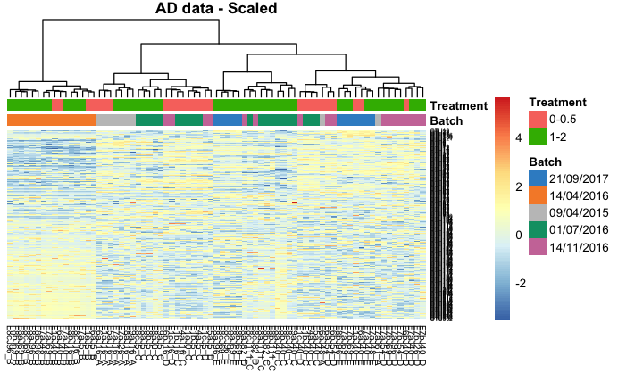

```r
# scale the clr data on both OTUs and samples
ad.clr.s <- scale(ad.clr, center = TRUE, scale = TRUE)
ad.clr.ss <- scale(t(ad.clr.s), center = TRUE, scale = TRUE)

ad.anno_col <- data.frame(Batch = ad.batch, Treatment = ad.trt)
ad.anno_colors <- list(Batch = color.mixo(seq_len(5)),
                       Treatment = pb_color(seq_len(2)))
names(ad.anno_colors$Batch) = levels(ad.batch)
names(ad.anno_colors$Treatment) = levels(ad.trt)

pheatmap(ad.clr.ss,
         cluster_rows = FALSE,
         fontsize_row = 4,
         fontsize_col = 6,
         fontsize = 8,
         clustering_distance_rows = 'euclidean',
         clustering_method = 'ward.D',
         treeheight_row = 30,
         annotation_col = ad.anno_col,
         annotation_colors = ad.anno_colors,
         border_color = 'NA',
         main = 'AD data - Scaled')
```

In the heatmap, samples from the batch dated “14/04/2016” clustered together and were distinct from the other samples, indicating a clear batch effect.

## Partial redundancy analysis (pRDA)

To quantitatively evaluate batch effects, we can apply pRDA with `varpart()` function from *vegan* R package.

```r
ad.factors.df <- data.frame(trt = ad.trt, batch = ad.batch)
head(ad.factors.df)
```

|  | trt | batch |
| --- | --- | --- |
| E1aJ16_A | 0-0.5 | 09/04/2015 |
| E5aJ16_A | 0-0.5 | 09/04/2015 |
| E6aJ16_A | 0-0.5 | 09/04/2015 |
| E6aJ48_A | 0-0.5 | 09/04/2015 |
| E7aJ16_A | 1-2 | 09/04/2015 |
| E7aJ26_A | 1-2 | 09/04/2015 |

```r
ad.rda.before <- varpart(ad.clr, ~ trt, ~ batch,
                         data = ad.factors.df, scale = TRUE)
ad.rda.before$part$indfract
```

|  | Df | R.squared | Adj.R.squared | Testable |
| --- | --- | --- | --- | --- |
| [a] = X1\|X2 | 1 | NA | 0.08943682 | TRUE |
| [b] = X2\|X1 | 4 | NA | 0.26604420 | TRUE |
| [c] | 0 | NA | 0.01296248 | FALSE |
| [d] = Residuals | NA | NA | 0.63155651 | FALSE |

In the result, `X1` and `X2` represent the first and second covariates fitted in the model. `[a]` and `[b]` indicate the independent proportions of variance explained by `X1` and `X2`, respectively, while `[c]` represents the shared variance between `X1` and `X2`. In the **AD data**, the variance explained by batch (`X2`) was larger than that explained by treatment (`X1`), with some intersection (shared variance) reflected in `[c]` (Adj.R.squared = 0.013). A greater shared variance suggests a more unbalanced batch × treatment design. Therefore, in this study, we considered the design to be approximately balanced.

# Managing batch effects

## Accounting for batch effects

The methods we use to account for batch effects include those specifically designed for microbiome data, such as the zero-inflated Gaussian mixture model (see the section “To go further”), as well as methods adapted for microbiome data, including linear regression, Surrogate variable analysis (SVA; see “To go further”) and Remove unwanted variation in 4 steps (RUV4). Among these, SVA and RUV4 are designed to handle unknown batch effects.

### Linear regression: linear model (LM) and linear mixed model (LMM)

Linear regression will be conducted using `linear_regres()` function in *PLSDAbatch*. We integrated the *performance* package, which assesses the performance of regression models, into function `linear_regres()`. Therefore, we can apply `check_model()` from *performance* to the outputs of `linear_regres()` to diagnose the validity of models fitted with treatment and batch factors for each variable (LÃŒdecke et al. 2020).

We can also extract performance metrics such as adjusted R2, RMSE, RSE, AIC and BIC for models fitted with and without batch factors, which are included in the outputs of `linear_regres()`.

Let’s apply `type = "linear model"` to the **AD data**, given its balanced batch x treatment design.

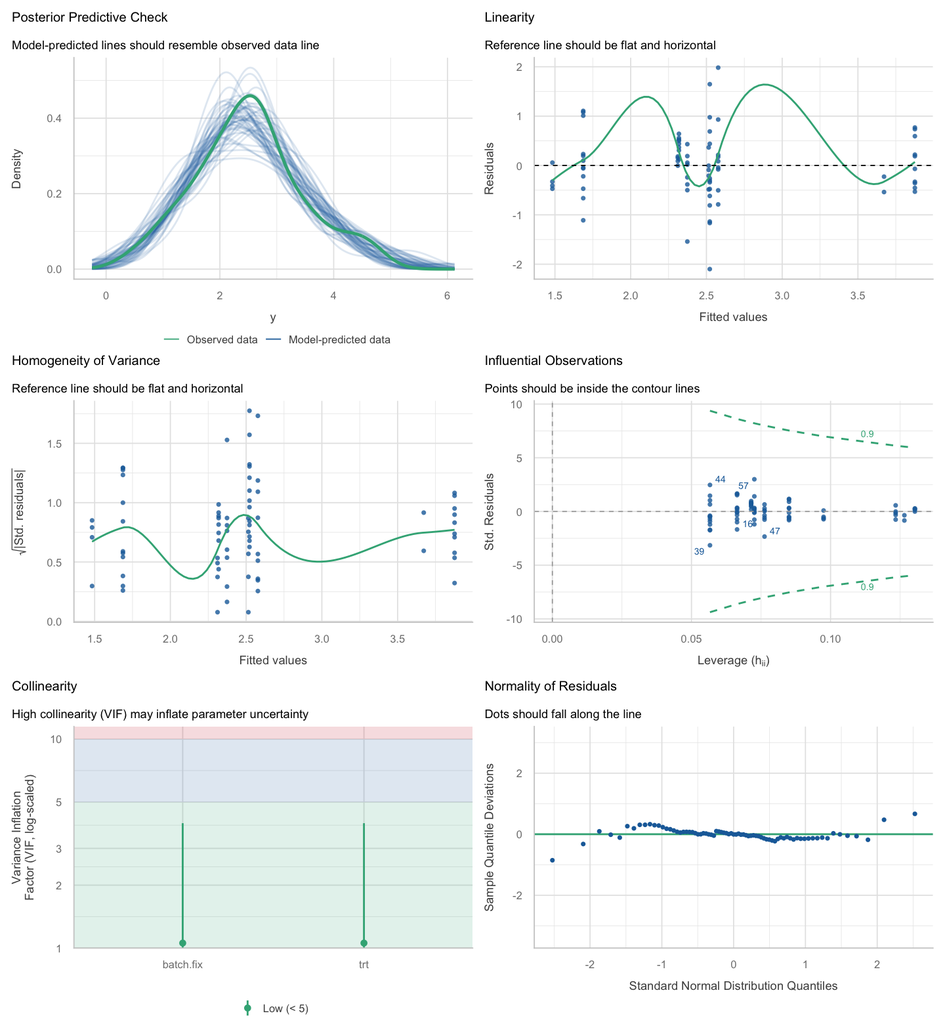

```r
ad.lm <- linear_regres(data = ad.clr,
                       trt = ad.trt,
                       batch.fix = ad.batch,
                       type = 'linear model',
                       p.adjust.method = 'fdr',
                       criterion = 'AIC')

check_model(ad.lm$model$OTU12)
```

To assess the validity of the model fitted with both treatment and batch factors, we can use diagnostic plots to check whether the assumptions are met for each microbial variable. For example, for “OTU12”, the assumptions of linearity (or homoscedasticity) and homogeneity of variance were not satisfied (top right & middle left). No sample was classified as an outlier with a Cook’s distance greater than or equal to 0.9, however, samples “57”, “39”, “47”, “44” and “16” were relatively close to the contour lines. The correlation between batch (`batch.fix`) and treatment (`trt`) factors was very low (< 5), indicating a well-fitted model with low collinearity (bottom left). The distribution of residuals was very close to normal (bottom panel). For microbial variables that violate some model assumptions, their results should be interpreted with caution.

The `criterion` is used to determine whether the model with or without batch factors should be preferred. Here, we have selected `AIC` as the criterion. For each microbial variable, the model with the lower AIC is considered to provide the better fit and is therefore preferred.

```r
ad.lm.best_model <- ad.lm$best.model
names(ad.lm.best_model) <- colnames(ad.clr)
head(ad.lm.best_model)
```

```
    OTU12     OTU29     OTU77     OTU86     OTU97    OTU106
trt.batch trt.batch trt.batch trt.batch trt.batch trt.batch
Levels: trt.only trt.batch
```

```r
head(ad.lm$AIC)
```

|  | trt.only | trt.batch |
| --- | --- | --- |
| OTU12 | 208.5626 | 164.13617 |
| OTU29 | 266.0485 | 154.99072 |
| OTU77 | 180.7800 | 134.80638 |
| OTU86 | 212.2987 | 206.13722 |
| OTU97 | 161.6715 | 119.90108 |
| OTU106 | 205.4135 | 59.17005 |

We can also examine other performance metrics, such as adjusted $R^2$. However, because adjusted $R^2$ was not selected as the model-selection criterion, it is not used to choose between the models with and without batch factors.

```r
head(ad.lm$adj.R2)
```

|  | trt.only | trt.batch |
| --- | --- | --- |
| OTU12 | 0.008445545 | 0.4785532 |
| OTU29 | -0.012966020 | 0.7808945 |
| OTU77 | -0.013343146 | 0.4779754 |
| OTU86 | 0.183743803 | 0.2850153 |
| OTU97 | -0.008989284 | 0.4502563 |
| OTU106 | 0.072963581 | 0.8745676 |

The choice of the better model depends strongly on the criterion selected.

We retain only the $p$-values from the preferred model, which can be obtained as follows:

```r
# adjusted p values
ad.p.adj <- ad.lm$adj.p
```

### Remove unwanted variation in 4 steps (RUV4)

Before applying RUV4 (`RUV4()` from *ruv* package), we need to specify negative control variables and the number of batch factors to estimate.

Empirical negative controls that are not significantly differentially abundant (adjusted P > 0.05), based on a linear regression using treatment information as the only covariate, can be used here. However, in this case, we assume that batch and treatment are not correlated; otherwise, the selection of empirical negative controls will be biased, and the final batch effect adjustment may be spurious.

Therefore, we will use a loop to fit a linear regression for each microbial variable and adjust the p values of the treatment effects for multiple comparisons using `p.adjust()` from *stats*. The empirical negative controls can then be identified based on the adjusted p values.

```r
# empirical negative controls
ad.empir.p <- c()
for(e in seq_len(ncol(ad.clr))){
  ad.empir.lm <- lm(ad.clr[,e] ~ ad.trt)
  ad.empir.p[e] <- summary(ad.empir.lm)$coefficients[2,4]
}
ad.empir.p.adj <- p.adjust(p = ad.empir.p, method = 'fdr')
ad.nc <- ad.empir.p.adj > 0.05
```

The number of batch factors `k` can be determined using `getK()` function.

```r
# estimate k
ad.k.res <- getK(Y = ad.clr, X = ad.trt, ctl = ad.nc)
ad.k <- ad.k.res$k
```

After all required parameters are estimated, let’s apply `RUV4()` with the known treatment variables, the selected negative control variables, and the estimated number of batch factors `k`. The resulting p values should also be adjusted for multiple comparisons.

```r
# RUV4
ad.ruv4 <- RUV4(Y = ad.clr, X = ad.trt, ctl = ad.nc, k = ad.k)
ad.ruv4.p <- ad.ruv4$p
ad.ruv4.p.adj <- p.adjust(ad.ruv4.p, method = "fdr")
```

Note: A package named *RUVSeq* has been developed for count data. It provides `RUVg()` which uses negative control variables, as well as other functions such as `RUVs()` and `RUVr()`, which use sample replicates (Moskovicz et al. 2020) or residuals from regression on treatment factors to estimate and account for latent batch effects. However, for CLR-transformed data, we still recommend using the standard *ruv* package.

Another method, SVA, which accounts for unknown batch effects, can be found in the section “To go further”.

## Correcting for batch effects

The methods we will use to correct for batch effects include ComBat, PLSDA-batch and Remove Unwanted Variation-III (RUVIII). Among these, RUVIII is designed to correct for unknown batch effects. Other methods, such as removeBatchEffect, sPLSDA-batch and percentile normalisation (PN), can be found in the section “To go further”.

### ComBat

The `ComBat()` function (from *sva* package) supports both parametric and non-parametric correction, controlled by the option `par.prior`. For parametric adjustment, the model’s validity can be assessed by setting `prior.plots = T` (Leek et al. 2012).

For the **AD data**, we apply non-parametric correction (`par.prior = FALSE`), using the input batch factor (`batch`) and the design matrix with the treatment factor (`mod`) to calculate the batch effect corrected data `ad.ComBat`. We chose the non-parametric approach based on the assumption that microbial abundance data, even after CLR transformation, may not follow a standard distribution.

```r
# the treatment design matrix
ad.mod <- model.matrix( ~ ad.trt)
ad.ComBat <- t(ComBat(t(ad.clr), batch = ad.batch,
                      mod = ad.mod, par.prior = FALSE))
```

### PLSDA-batch

Before applying PLSDA-batch, we need to specify the optimal number of components related to treatment (`ncomp.trt`) and batch effects (`ncomp.bat`).

In PLSDA-based methods, a categorical `Y` variable is converted into a 0/1 dummy matrix, A `Y` variable with $k$ classes becomes a matrix with $k$ columns, but only $k-1$ of these are informative because the final column can always be derived from the others. Mathmetically, the rank of `Y` matrix is $k-1$.

In the **AD data**, `ad.trt` has 2 classes and `ad.batch` has 5 batches, so we choose 1 component for the treatment effect and 4 components for the batch effect.

Here, we use the default `regression` mode, which is also the recommended mode. In this application, our goal is to understand how `X` explains and predicts `Y`: specifically, to remove the variation in `X` that explains `Y.batch` while preserving the variation in `X` that explains `Y.trt`.

```r
# the optimal number of treatment components
nlevels(ad.trt) - 1
```

```
[1] 1
```

```r
# the optimal number of batch components
nlevels(ad.batch) - 1
```

```
[1] 4
```

```r
ad.PLSDA_batch.res <- PLSDA_batch(X = ad.clr,
                                  Y.trt = ad.trt, Y.bat = ad.batch,
                                  ncomp.trt = 1, ncomp.bat = 4,
                                  mode = "regression"
)
ad.PLSDA_batch <- ad.PLSDA_batch.res$X.nobatch
```

Note: Comparatively, PLSDA-batch (*PLSDAbatch* package) is more suitable for weak batch effects, while from the same package, sparse PLSDA-batch is better suited for strong batch effects (see section “To go further”), weighted PLSDA-batch is specifically designed for unbalanced but not nested batch x treatment designs.

### Remove Unwanted Variation-III (RUVIII)

The `RUVIII()` function is from *ruv* package. Similar to `RUV4()`, it requires empirical negative control variables and the number of unwanted factors (`k`) to remove. We will use those estimated in the RUV4 section. In addition, it requires sample replicates, which should be structured into a mapping matrix using `replicate.matrix()`. With these elements, we can then obtain the batch effect corrected data by applying `RUVIII()`.

```r
ad.metadata <- example_ADdata$metadata
ad.replicates <- ad.metadata$sample_name.data.extraction
head(table(ad.replicates, ad.batch))
```

```
             ad.batch
ad.replicates 21/09/2017 14/04/2016 09/04/2015 01/07/2016 14/11/2016
       E1aJ0           0          0          0          1          0
       E1aJ16          0          0          1          0          0
       E1aJ40          1          1          0          0          0
       E1aJ5           0          1          0          0          0
       E1bJ16          0          0          0          1          0
       E1bJ40          0          0          0          1          0
```

```r
ad.replicates.matrix <- replicate.matrix(ad.replicates)

ad.RUVIII <- RUVIII(Y = ad.clr, M = ad.replicates.matrix,
                    ctl = ad.nc, k = ad.k)
rownames(ad.RUVIII) <- rownames(ad.clr)
```

# Assessing batch effect correction

## Methods that detect batch effects

### PCA

First, we can compare the PCA sample plots before and after batch effect correction using different methods.

```r
ad.pca.before <- mixOmics::pca(ad.clr, ncomp = 3, scale = TRUE)
ad.pca.ComBat <- mixOmics::pca(ad.ComBat, ncomp = 3, scale = TRUE)
ad.pca.PLSDA_batch <- mixOmics::pca(ad.PLSDA_batch, ncomp = 3, scale = TRUE)
ad.pca.RUVIII <- mixOmics::pca(ad.RUVIII, ncomp = 3, scale = TRUE)
```

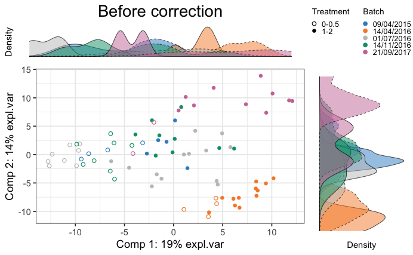

```r
# order batches
ad.batch = factor(ad.metadata$sequencing_run_date,
                  levels = unique(ad.metadata$sequencing_run_date))

ad.pca.before.plot <- Scatter_Density(components = ad.pca.before$variates$X,
                                      comp = c(1, 2),
                                      expl.var = ad.pca.before$prop_expl_var$X,
                                      batch = ad.batch,
                                      trt = ad.trt,
                                      title = 'Before correction',
                                      color.set = color.mixo(1:5))
```

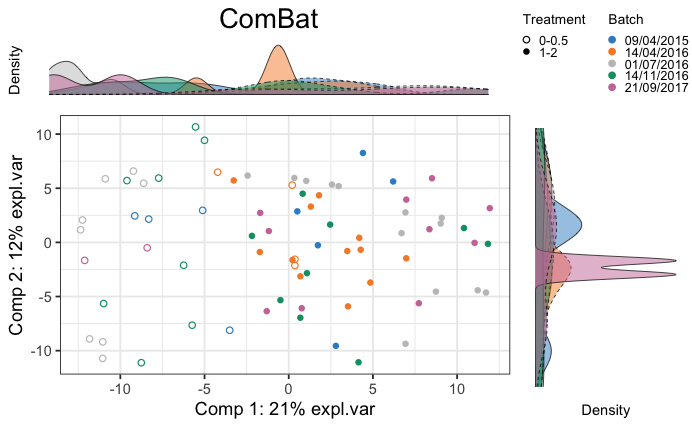

```r
ad.pca.ComBat.plot <- Scatter_Density(components = ad.pca.ComBat$variates$X,
                                      comp = c(1, 2),
                                      expl.var = ad.pca.ComBat$prop_expl_var$X,
                                      batch = ad.batch,
                                      trt = ad.trt,
                                      title = 'ComBat',
                                      color.set = color.mixo(1:5))
```

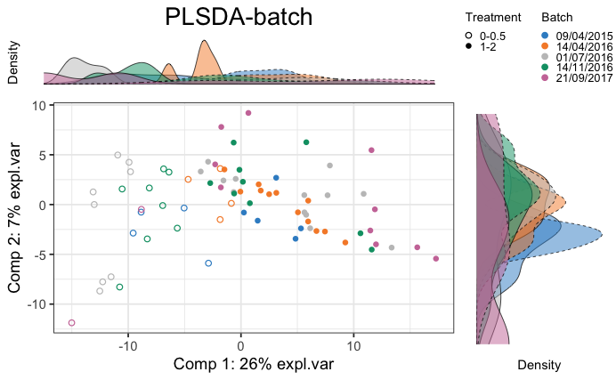

```r
ad.pca.PLSDA_batch.plot <- Scatter_Density(components = ad.pca.PLSDA_batch$variates$X,
                                           comp = c(1, 2),
                                           expl.var = ad.pca.PLSDA_batch$prop_expl_var$X,
                                           batch = ad.batch,
                                           trt = ad.trt,
                                           title = 'PLSDA-batch',
                                           color.set = color.mixo(1:5))
```

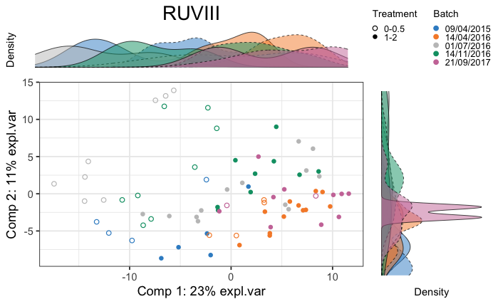

```r
ad.pca.RUVIII.plot <- Scatter_Density(components = ad.pca.RUVIII$variates$X,
                                      comp = c(1, 2),
                                      expl.var = ad.pca.RUVIII$prop_expl_var$X,
                                      batch = ad.batch,
                                      trt = ad.trt,
                                      title = 'RUVIII',
                                      color.set = color.mixo(1:5))
```

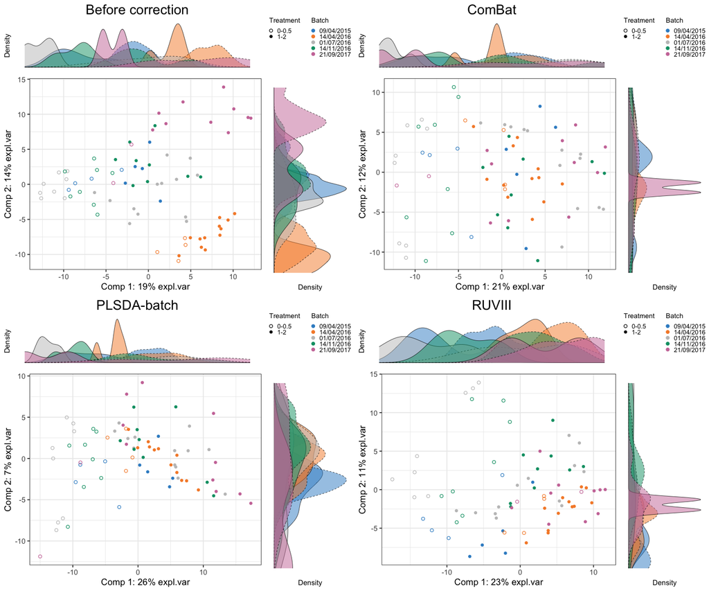

#### Exercise 4: Interpret the PCA plots created above

We can also compare boxplots and density plots of key variables identified by PCA, as well as heatmaps that highlight distinct patterns before and after batch effect correction. However, due to time limitations, we will not show the results here.

### pRDA

As a quantitative measure, we can calculate the global explained variance across all microbial variables using pRDA. The results can be visualised using `partVar_plot()` from *PLSDAbatch* package.

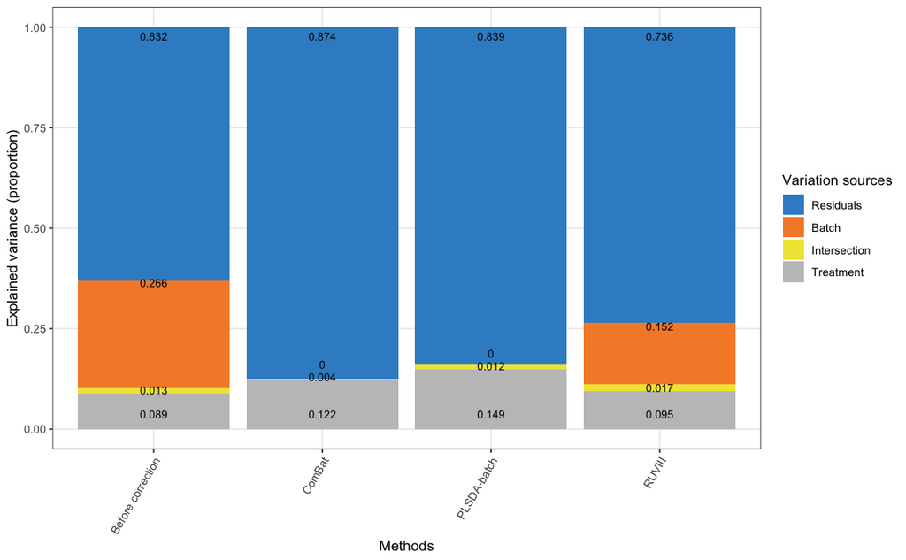

```r
# arrange data before and after batch effect correction into a list
ad.corrected.list <- list(`Before correction` = ad.clr,
                          ComBat = ad.ComBat,
                          `PLSDA-batch` = ad.PLSDA_batch,
                          RUVIII = ad.RUVIII)

ad.prop.df <- data.frame(Treatment = NA, Batch = NA,
                         Intersection = NA,
                         Residuals = NA)

# run rda in a loop
for(i in seq_len(length(ad.corrected.list))){
  rda.res = varpart(ad.corrected.list[[i]], ~ trt, ~ batch,
                    data = ad.factors.df, scale = TRUE)
  ad.prop.df[i, ] <- rda.res$part$indfract$Adj.R.squared}

rownames(ad.prop.df) = names(ad.corrected.list)

# change the order of explained variance
ad.prop.df <- ad.prop.df[, c(1,3,2,4)]

# remove values less than zero, and recalculate the proportions
ad.prop.df[ad.prop.df < 0] = 0
ad.prop.df <- as.data.frame(t(apply(ad.prop.df, 1,
                                    function(x){x/sum(x)})))

partVar_plot(prop.df = ad.prop.df, color.set = color.mixo(c(3,6,2,1)))
```

As shown in the figure above, the intersection between batch and treatment variance was small (1.3%), indicating that the batch x treatment design is not highly unbalanced. As a result, unweighted PLSDA-batch remained applicable, and the weighted version was not used. Among all methods, the data corrected with PLSDA-batch showed the best performance, explaining a higher proportion of treatment variance compared to the others. Notably, replicates in **AD data** are not present across all batches, highlighting the critical role of sample replicates in the effectiveness of RUVIII. Therefore, we calculated pseudo replicates and recalculated the batch effect corrected data. The result showed clear improvement, which can be found in the section “To go further”.

## Other methods

### $\mathbf{R^2}$

We can also calculate the $R^2$ from one-way ANOVA for each variable to evaluate the proportion of explained variance, using `lm()` from *stats* package. To ensure comparability of $R^2$ values across variables, we will scale the corrected data prior to the $R^2$ calculation. The results will then be visualised by `ggplot()` from *ggplot2* R package.

```r
# scale
ad.corr_scale.list <- lapply(ad.corrected.list,
                             function(x){apply(x, 2, scale)})

# perform one-way ANOVA on each variable within each dataset
ad.r_values.list <- list()
for(i in seq_len(length(ad.corr_scale.list))){
  # for each dataset
  ad.r_values <- data.frame(trt = NA, batch = NA)
  for(c in seq_len(ncol(ad.corr_scale.list[[i]]))){
    # for each variable
    ad.fit.res.trt <- lm(ad.corr_scale.list[[i]][,c] ~ ad.trt)
    ad.r_values[c,1] <- summary(ad.fit.res.trt)$r.squared
    ad.fit.res.batch <- lm(ad.corr_scale.list[[i]][,c] ~ ad.batch)
    ad.r_values[c,2] <- summary(ad.fit.res.batch)$r.squared
  }
  ad.r_values.list[[i]] <- ad.r_values
}
names(ad.r_values.list) <- names(ad.corr_scale.list)
head(ad.r_values.list$`Before correction`)
```

|  | trt | batch |
| --- | --- | --- |
| 1 | 0.0218449290 | 0.5038161 |
| 2 | 0.0007227095 | 0.7716320 |
| 3 | 0.0003506800 | 0.5082321 |
| 4 | 0.1947742926 | 0.1489019 |
| 5 | 0.0046457059 | 0.4590567 |
| 6 | 0.0854911001 | 0.8562416 |

```r
# generate boxplots for each dataset
ad.boxp.list <- list()
for(i in seq_len(length(ad.r_values.list))){
  ad.boxp.list[[i]] <-
    data.frame(r2 = c(ad.r_values.list[[i]][ ,'trt'],
                      ad.r_values.list[[i]][ ,'batch']),
               Effects = as.factor(rep(c('Treatment','Batch'),
                                       each = 231)))
}
names(ad.boxp.list) <- names(ad.r_values.list)
head(ad.boxp.list$`Before correction`)
```

|  | r2 | Effects |
| --- | --- | --- |
| 1 | 0.0218449290 | Treatment |
| 2 | 0.0007227095 | Treatment |
| 3 | 0.0003506800 | Treatment |
| 4 | 0.1947742926 | Treatment |
| 5 | 0.0046457059 | Treatment |
| 6 | 0.0854911001 | Treatment |

```r
ad.r2.boxp <- rbind(ad.boxp.list$`Before correction`,
                    ad.boxp.list$ComBat,
                    ad.boxp.list$`PLSDA-batch`,
                    ad.boxp.list$RUVIII)

ad.r2.boxp$methods <- rep(c('Before correction',
                            'ComBat','PLSDA-batch',
                            'RUVIII'), each = 462)

ad.r2.boxp$methods <- factor(ad.r2.boxp$methods,
                             levels = unique(ad.r2.boxp$methods))
head(ad.r2.boxp)
```

|  | r2 | Effects | methods |
| --- | --- | --- | --- |
| 1 | 0.0218449290 | Treatment | Before correction |
| 2 | 0.0007227095 | Treatment | Before correction |
| 3 | 0.0003506800 | Treatment | Before correction |
| 4 | 0.1947742926 | Treatment | Before correction |
| 5 | 0.0046457059 | Treatment | Before correction |
| 6 | 0.0854911001 | Treatment | Before correction |

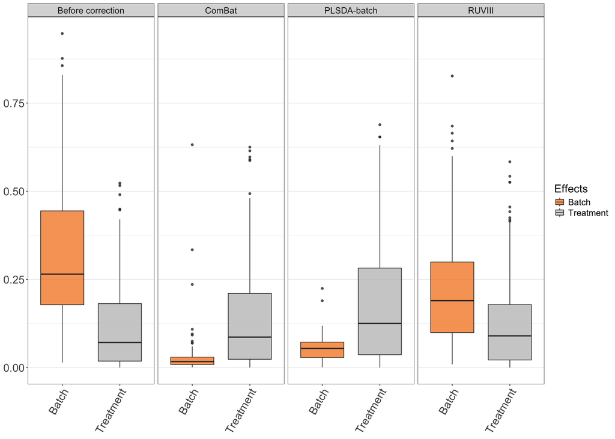

```r
ggplot(ad.r2.boxp, aes(x = Effects, y = r2, fill = Effects)) +
  geom_boxplot(alpha = 0.80) +
  theme_bw() +
  theme(text = element_text(size = 18),
        axis.title.x = element_blank(),
        axis.title.y = element_blank(),
        axis.text.x = element_text(angle = 60, hjust = 1, size = 18),
        axis.text.y = element_text(size = 18),
        panel.grid.minor.x = element_blank(),
        panel.grid.major.x = element_blank(),
        legend.position = "right") + facet_grid( ~ methods) +
  scale_fill_manual(values=pb_color(c(12,14)))
```

As shown in the plots, the data corrected using ComBat still contained a few variables with a large proportion of batch variance. In the case of RUVIII, the corrected data exhibited a greater proportion of batch variance than treatment variance.

### Alignment scores

Before applying `alignment_score()` function from *PLSDAbatch*, we need to specify the proportion of data variance to explain (`var`), the number of nearest neighbours (`k`) and the number of PCs to calculate (`ncomp`) for the internal PCA. We can then use `ggplot()` function from *ggplot2* to visualise the results.

```r
# calculate the alignment scores
ad.scores <- c()
names(ad.batch) <- rownames(ad.clr)
for(i in seq_len(length(ad.corrected.list))){
  res <- alignment_score(data = ad.corrected.list[[i]],
                         batch = ad.batch,
                         var = 0.95,
                         k = 8,
                         ncomp = 50)
  ad.scores <- c(ad.scores, res)
}
head(ad.scores)
```

```
[1] 0.3800676 0.7179054 0.6638514 0.5287162
```

```r
# rearrange the data for ggplot
ad.scores.df <- data.frame(scores = ad.scores,
                           methods = names(ad.corrected.list))

ad.scores.df$methods <- factor(ad.scores.df$methods,
                               levels = rev(names(ad.corrected.list)))

head(ad.scores.df)
```

|  | scores | methods |
| --- | --- | --- |
| 1 | 0.3800676 | Before correction |
| 2 | 0.7179054 | ComBat |
| 3 | 0.6638514 | PLSDA-batch |
| 4 | 0.5287162 | RUVIII |

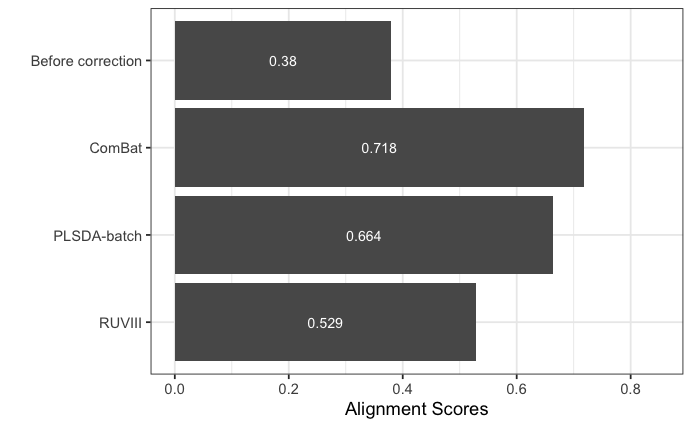

```r
ggplot() + geom_col(aes(x = ad.scores.df$methods,
                        y = ad.scores.df$scores)) +
  geom_text(aes(x = ad.scores.df$methods,
                y = ad.scores.df$scores/2,
                label = round(ad.scores.df$scores, 3)),
            size = 3, col = 'white') +
  coord_flip() + theme_bw() + ylab('Alignment Scores') +
  xlab('') + ylim(0,0.85)
```

The alignment scores complement the PCA results, especially when batch effect removal is difficult to evaluate from PCA sample plots alone. For example, in the previous PCA plots (see section “PCA”), we observed that samples from different batches appeared more intermixed after batch effect correction, regardless of the method used. However, comparing the performance of different methods remained challenging.

Since a higher alignment score indicates better mixing of samples across batches, the bar plot above shows that ComBat achieved superior performance compared to the other methods. However, the $R^2$ analysis revealed that the data corrected with ComBat still contained a few variables with a large proportion of batch variance (see section “$R^2$”). This highlights the importance of evaluating correction effectiveness using multiple techniques to ensure an unbiased assessment.

In this example, the lower alignment score observed for the data corrected using PLSDA-batch compared to ComBat may be due to differences in the PCA sample projections. Specifically, the data corrected with ComBat exhibited greater variance in its PCA projection, whereas the data with PLSDA-batch showed smaller variance. Smaller variance in the projection can lead to lower alignment scores, as it increases the likelihood that samples from different batches appear as nearest neighbours. Nonetheless, the pRDA results (see section “pRDA”) quantitatively confirmed that PLSDA-batch effectively removed batch variance entirely (Wang and Lê Cao 2023).

# Discussion and conclusions

This workshop presents a comprehensive framework for managing batch effects, using microbiome data as an illustrative example. The input for this workflow is preprocessed data. For different types of omics data, the preprocessing steps may vary.

To detect batch effects, both visual tools (e.g., PCA, boxplots, density plots, and heatmaps) and quantitative methods such as pRDA can be applied. If batch effects appear negligible, for instance, when pRDA shows only a minimal proportion of variance explained by batch or when PCA does not reveal clear batch driven clusters, batch effect management may not be necessary. However, when batch effects are substantial, two strategies can be considered: accounting for batch effects during modeling, or removing them from the data prior to analysis.

Both strategies assume a balanced batch × treatment design. If the design is nested, batch effects can only be accounted for using a linear mixed model. If the design is unbalanced but not nested, batch effects can either be controlled using standard linear models or removed using weighted PLSDA-batch.

In most cases, batch factors are assumed to be known. When it is not, batch estimation methods such as RUV4, RUVIII and SVA can be employed. RUV-based methods rely on negative control variables and/or sample replicates, while SVA estimates batch effects from variables that are least affected by treatment (see section “To go further”). However, for RUV methods, these negative controls and sample replicates must capture the full spectrum of batch variation; otherwise, batch effects may not be completely addressed. We emphasised this issue in the section “Assessing batch effect correction - pRDA”, where limited replicates posed challenges for batch effect removal. Moreover, some estimation methods (e.g., SVA) assume that batch effects are independent of treatment. When batch and treatment are correlated, the batch effect cannot be accurately estimated and may lead to spurious associations.

Additionally, some methods for batch effect management assume systematic batch effects across variables, and are highly influenced by this assumption (e.g., SVA, ComBat and RUV methods). Therefore, we recommend validating the model before applying it. For an appropriate choice of method, see the figure below: Decision tree for method selection.

The next critical step is to evaluate the effectiveness of batch effect management. While such evaluation is often implicit in methods that account for batch effects (e.g., linear regression), it is essential for methods that remove them. This can be done by comparing the data before and after correction using the same tools employed for batch effect detection. Additionally, $R^2$ values can be calculated for each microbial variable to quantify the variance explained by batch and treatment, and alignment scores can be used to assess how well samples from different batches are mixed. However, individual evaluation tools may have limitations. For example, PCA relies on visual interpretation, while alignment scores focus solely on distances in the PCA projection space. Therefore, a robust conclusion should be based on multiple complementary evaluation methods.

Once batch effects have been adequately removed, the corrected data can be used in downstream analyses such as dimension reduction, visualisation, clustering, network analysis, data integration and prediction. For variable selection or biomarker discovery, however, I recommend accounting for batch effects directly within the statistical model rather than first correcting the data and then performing variable selection. This two-step approach adjusts the microbial profiles but does not model the relationship between the treatment and the batch factor. When the batch and treatment factors are associated, this mismatch may create false signals or weaken true microbiome–treatment associations.

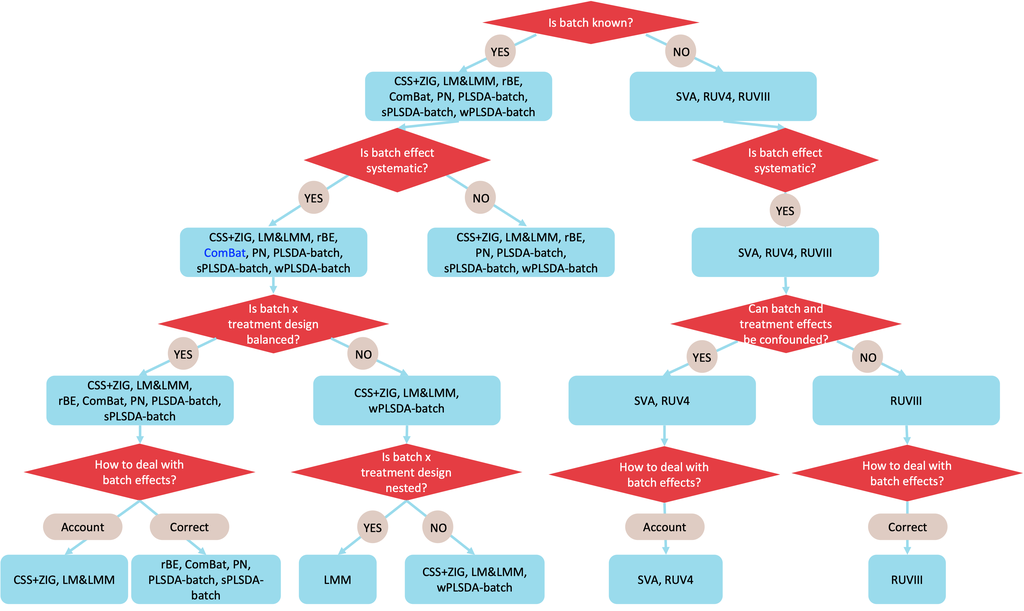

**Decision tree for method selection.**

# To go further

Due to time limitations, the methods shown in the decision tree that we don’t have time to cover in practice are presented in the following section.

## Accounting for batch effects

### Methods designed for microbiome data

#### Zero-inflated Gaussian mixture model (CSS+ZIG)

To use the ZIG model, we first need to create an `MRexperiment` object by applying `newMRexperiment()` (from *metagenomeSeq* package) to the microbiome count data, along with annotated dataframes containing metadata and taxonomic information, respectively, which are generated using `AnnotatedDataFrame()` from *Biobase* package.

```r
# Creating a MRexperiment object (make sure no NA in metadata)
## metadata
AD.phenotypeData = AnnotatedDataFrame(data = as.data.frame(ad.metadata))

## taxonomic info
AD.taxaData = AnnotatedDataFrame(data = as.data.frame(example_ADdata$taxa))

AD.obj = newMRexperiment(counts = t(example_ADdata$count),
                         phenoData = AD.phenotypeData,
                         featureData = AD.taxaData)
AD.obj
```

```
MRexperiment (storageMode: environment)
assayData: 567 features, 75 samples
  element names: counts
protocolData: none
phenoData
  sampleNames: E1aJ16_A E5aJ16_A ... E8cJ96_E (75 total)
  varLabels: sample_name.data.extraction analysis_name ...
    initial_phenol_concentration.regroup (7 total)
  varMetadata: labelDescription
featureData
  featureNames: OTU12 OTU29 ... OTU17710 (567 total)
  fvarLabels: Kingdom Phylum ... Species (7 total)
  fvarMetadata: labelDescription
experimentData: use 'experimentData(object)'
Annotation:
```

The **AD count data** are then filtered using `filterData()` function (from *metagenomeSeq* package).

To extract the count data from the `MRexperiment` object, we can use `MRcounts()` function.

```r
# filtering data to maintain a threshold of minimum depth or OTU presence

## before filtering
dim(MRcounts(AD.obj))
```

```
[1] 567  75
```

```r
AD.obj = filterData(obj = AD.obj, present = 20, depth = 5)

## after filtering
dim(MRcounts(AD.obj))
```

```
[1] 289  75
```

After filtering, the **AD count data** were reduced to 289 OTUs and 75 samples.

We will then calculate the percentile for CSS normalisation using `cumNormStatFast()` function (from *metagenomeSeq* package). CSS normalisation can be applied with `cumNorm()` and the normalised data can be exported using `MRcounts()` with `norm = TRUE`. The normalisation scaling factors for each sample, which are the sum of counts up to the calculated percentile, can be accessed using `normFactors()`. We can calculate the log-transformed scaling factors by diving them with their median, which are preferred over the default scaling factors that are divided by 1000 (`log2(normFactors(obj)/1000 + 1)`).

```r
# calculate the percentile for CSS normalisation
AD.pctl = cumNormStatFast(obj = AD.obj)

# CSS normalisation
AD.obj <- cumNorm(obj = AD.obj, p = AD.pctl)

# export normalised data
AD.norm.data <- MRcounts(obj = AD.obj, norm = TRUE)

# normalisation scaling factors for each sample
AD.normFactor = normFactors(object = AD.obj)

# log-transformed scaling factors
AD.normFactor = log2(AD.normFactor/median(AD.normFactor) + 1)
```

After that, let’s create a design matrix with the treatment variable (`phenol_conc`), batch variable (`seq_run`) and the log-transformed scaling factors using `model.matrix()`. We can then apply the ZIG model using `fitZig()` function. The argument `useCSSoffset = FALSE` should be set to avoid using the default scaling factors, as we have already included our customised scaling factor (`AD.normFactor`) in the design matrix.

```r
# treatment variable
phenol_conc = pData(object = AD.obj)$initial_phenol_concentration.regroup

# batch variable
seq_run = pData(object = AD.obj)$sequencing_run_date

# build a design matrix
AD.mod.full = model.matrix(~ phenol_conc + seq_run + AD.normFactor)

# settings for the fitZig() function
AD.settings <- zigControl(maxit = 10, verbose = TRUE)

# apply the ZIG model
ADfit <- fitZig(obj = AD.obj,
                mod = AD.mod.full,
                useCSSoffset = FALSE,
                control = AD.settings)
```

```
it= 0, nll=123.44, log10(eps+1)=Inf, stillActive=289
it= 1, nll=134.33, log10(eps+1)=0.04, stillActive=10
it= 2, nll=134.64, log10(eps+1)=0.01, stillActive=1
it= 3, nll=134.80, log10(eps+1)=0.00, stillActive=0
```

```r
head(ADfit@fit$coefficients)
```

```
       (Intercept) phenol_conc1-2 seq_run09/04/2015 seq_run14/04/2016
OTU12   0.81493490     0.68096987        -0.3914984       -0.46251653
OTU29   0.13034146    -0.74964792         3.2036768        1.73851963
OTU77  -0.03529492     0.03456233        -0.4279860       -0.69409045
OTU86   0.69888725    -1.18545474        -0.9872078       -0.74385441
OTU97  -0.23371589    -0.21160945        -1.0906897        0.02215167
OTU106 -0.62766893     0.13556615         2.9251996        0.21997853
       seq_run14/11/2016 seq_run21/09/2017 AD.normFactor
OTU12         0.03486566         0.2163230     4.3931417
OTU29         1.58298972         5.6148999     1.3016901
OTU77         0.59730201         1.4620328     2.0975373
OTU86         0.28063764         0.6643703     2.6490927
OTU97         0.14623346         0.9857519     2.3412736
OTU106        0.15511965         4.1640912     0.5575642
```

The OTUs with the top 50 smallest p values can be extracted using `MRcoefs()`. Let’s set `eff = 0.5` so that only OTUs with at least the “0.5” quantile (50%) number of effective samples (i.e., positive samples + estimated undersampling zeroes) are extracted.

We also set the arguments `coef = 2` to focus on the second column of the coefficient matrix, which corresponds to the treatment effects, and `group = 3` to sort the OTUs by their p values in increasing order.

```r
ADcoefs <- MRcoefs(ADfit, coef = 2,
                   group = 3, number = 50,
                   eff = 0.5)
head(ADcoefs)
```

|  | phenol_conc1-2 | pvalues | adjPvalues |
| --- | --- | --- | --- |
| OTU68 | -2.901041 | 2.467451e-15 | 4.081959e-13 |
| OTU46 | -2.847212 | 2.824885e-15 | 4.081959e-13 |
| OTU28 | -2.449290 | 4.012023e-14 | 3.864915e-12 |
| OTU24 | -2.846452 | 6.397959e-14 | 4.622526e-12 |
| OTU59 | -1.815250 | 3.784889e-13 | 2.187666e-11 |
| OTU65 | -2.141183 | 3.342621e-11 | 1.610029e-09 |

### Methods adapted for microbiome data

#### Surrogate variable analysis (SVA)

SVA only accounts for unknown batch effects. Therefore, we assume that the batch factor in the **AD data** is unknown, and that the batch effects are systematic.

We first need to build two design matrices with (`ad.mod`) and without (`ad.mod0`) the treatment factor using `model.matrix()` function from *stats*. We will then use `num.sv()` from *sva* package to determine the number of surrogate or batch-related variables `n.sv` to estimate in function `sva()`.

```r
# the design with treatment
ad.mod <- model.matrix( ~ ad.trt)
# the design without treatment
ad.mod0 <- model.matrix( ~ 1, data = ad.trt)

# estimate the number of batch-related variables
ad.sva.n <- num.sv(dat = t(ad.clr), mod = ad.mod, method = 'leek')

# estimate batch-related variables
ad.sva <- sva(t(ad.clr),
              ad.mod, ad.mod0,
              n.sv = ad.sva.n)
```

```
Number of significant surrogate variables is:  4
Iteration (out of 5 ):1  2  3  4  5
```

The estimated batch factors are then input into `f.pvalue()` to calculate the p values of treatment effects. In SVA, batch factors are assumed to be independent of treatment factors. If they are correlated due to study design or biological reasons, the estimation of batch-related variables will be biased and may affect the accuracy of downstream linear regression results. However, some correlation may exist between the estimated batch factors and treatment due to how SVA estimates batch-related variables from those least affected by treatment. These variables may still carry some treatment variation, leading to estimated batch factors that are weakly correlated with treatment factors. (Wang and LêCao 2020).

```r
# include estimated batch-related variables in the linear model
ad.mod.batch <- cbind(ad.mod, ad.sva$sv)
ad.mod0.batch <- cbind(ad.mod0, ad.sva$sv)

# linear model
ad.sva.p <- f.pvalue(t(ad.clr), ad.mod.batch, ad.mod0.batch)
ad.sva.p.adj <- p.adjust(ad.sva.p, method = 'fdr')
```

## Correcting for batch effects

### removeBatchEffect

Before applying removeBatchEffect, we need to prepare a design matrix (`ad.mod`) that includes the treatment factor, which is used to preserve treatment effects during batch effect correction. This design matrix can be generated using `model.matrix()` function from *stats*.

Then we can use `removeBatchEffect()` function (*limma* package) with the batch factor (`batch`) and the treatment design matrix (`design`) as inputs to calculate the batch effect corrected data `ad.rBE`.

```r
# generate treatment design matrix
ad.mod <- model.matrix( ~ ad.trt)

ad.rBE <- t(removeBatchEffect(t(ad.clr),
                              batch = ad.batch,
                              design = ad.mod))
```

### sPLSDA-batch

Applying sPLSDA-batch is similar to applying PLSDA-batch. We will use the same function `PLSDA_batch()`, but need to specify the number of variables to select on each component, typically for the treatment-related components (`keepX.trt`). To determine the optimal number of variables to select, we will use `tune.splsda()` function from *mixOmics* package (Rohart et al. 2017), testing a range of possible values for each component (`test.keepX`).

```r
# estimate the number of variables to select per treatment component
# generate a range of possible values
ad.test.keepX = c(seq(1, 10, 1), seq(20, 100, 10),
                  seq(150, 231, 50), 231)

ad.trt.tune.v <- tune.splsda(X = ad.clr,
                             Y = ad.trt,
                             ncomp = 1,
                             test.keepX = ad.test.keepX,
                             validation = 'Mfold',
                             folds = 4,
                             nrepeat = 50,
                             seed = 777)
ad.trt.tune.v$choice.keepX #100
```

Here, the optimal number of variables to select for the treatment component is 100.

```r
ad.sPLSDA_batch.res <- PLSDA_batch(X = ad.clr,
                                   Y.trt = ad.trt, Y.bat = ad.batch,
                                   ncomp.trt = 1, keepX.trt = 100,
                                   ncomp.bat = 4, mode = "regression")
ad.sPLSDA_batch <- ad.sPLSDA_batch.res$X.nobatch
```

Note: For an unbalanced batch x treatment design (except in the case of a nested design), we can set `balance = FALSE` in `PLSDA_batch()` function to apply weighted PLSDA-batch.

### Percentile Normalisation (PN)

For PN correction, let’s apply `percentile_norm()` function from *PLSDAbatch* package and specify a control group (`ctrl.grp`).

```r
set.seed(777)
ad.PN <- percentile_norm(data = ad.clr, batch = ad.batch,
                         trt = ad.trt, ctrl.grp = "0-0.5")
```

### RUVIII with pseudo replicates

In the previous RUVIII application using the AD study’s original sample replicates, the result was poor due to uneven representation of replicates across batches. To address this, we will generate pseudo-replicates by calculating the sample mean of each batch within each treatment group. Since the means across batches are expected to be similar for the same treatment, these pseudo-replicates can serve as substitutes for actual replicates.

```r
# add group means as the pseudo-replicates
ad_group_mean <- matrix(ncol = ncol(ad.clr))
ad_mean_trt_lab <- c()
ad_mean_batch_lab <- c()
for(te in levels(ad.trt)){
  for(be in levels(ad.batch)){
    ad_group_mean <- rbind(ad_group_mean,apply(ad.clr[ad.trt == te & ad.batch == be, ], 2, mean))
    ad_mean_trt_lab <- c(ad_mean_trt_lab, te)
    ad_mean_batch_lab <- c(ad_mean_batch_lab, be)
  }
}
ad_group_mean <- ad_group_mean[-1,]
ad_new_ind <- rep(c("mean1", "mean2"), each = 5)


ad.replicates.new <- as.factor(c(as.character(ad.metadata$sample_name.data.extraction), ad_new_ind))
ad.replicates.matrix.new <- replicate.matrix(ad.replicates.new)
ad.clr.new <- rbind(ad.clr, ad_group_mean)
ad.trt.new <- as.factor(c(as.character(ad.trt), ad_mean_trt_lab))
ad.batch.new <- as.factor(c(as.character(ad.batch), ad_mean_batch_lab))

# recalculate empirical negative controls
ad.empir.p.new <- c()
for(e in seq_len(ncol(ad.clr.new))){
  ad.empir.lm <- lm(ad.clr.new[,e] ~ ad.trt.new)
  ad.empir.p.new[e] <- summary(ad.empir.lm)$coefficients[2,4]
}
ad.empir.p.adj.new <- p.adjust(p = ad.empir.p.new, method = 'fdr')
ad.nc.new <- ad.empir.p.adj.new > 0.05

# estimate k
ad.k.res.new <- getK(Y = ad.clr.new, X = ad.trt.new, ctl = ad.nc.new)
ad.k.new <- ad.k.res.new$k

# RUVIII
ad.RUVIII.new <- RUVIII(Y = ad.clr.new,
                        M = ad.replicates.matrix.new,
                        ctl = ad.nc.new,
                        k = ad.k.new)

rownames(ad.RUVIII.new) <- rownames(ad.clr.new)
```

## Assessing batch effect correction

### PCA

Here, we compare the PCA sample plots before and after batch effect correction using all methods presented in the workshop.

```r
ad.pca.before <- mixOmics::pca(ad.clr, ncomp = 3, scale = TRUE)
ad.pca.rBE <- mixOmics::pca(ad.rBE, ncomp = 3, scale = TRUE)
ad.pca.ComBat <- mixOmics::pca(ad.ComBat, ncomp = 3, scale = TRUE)
ad.pca.PLSDA_batch <- mixOmics::pca(ad.PLSDA_batch, ncomp = 3, scale = TRUE)
ad.pca.sPLSDA_batch <- mixOmics::pca(ad.sPLSDA_batch, ncomp = 3, scale = TRUE)
ad.pca.PN <- mixOmics::pca(ad.PN, ncomp = 3, scale = TRUE)
ad.pca.RUVIII <- mixOmics::pca(ad.RUVIII, ncomp = 3, scale = TRUE)
ad.pca.RUVIII.new <- mixOmics::pca(ad.RUVIII.new, ncomp = 3, scale = TRUE)
```

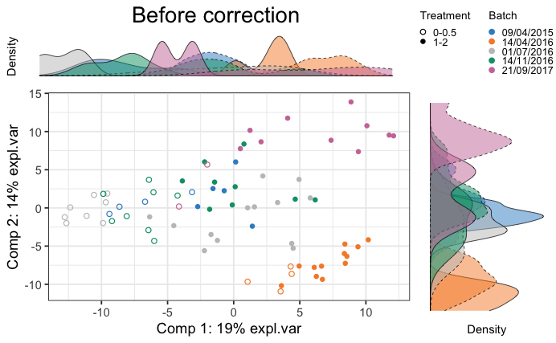

```r
# order batches
ad.batch = factor(ad.metadata$sequencing_run_date,
                  levels = unique(ad.metadata$sequencing_run_date))

ad.pca.before.plot <- Scatter_Density(components = ad.pca.before$variates$X,
                                      comp = c(1, 2),
                                      expl.var = ad.pca.before$prop_expl_var$X,
                                      batch = ad.batch,
                                      trt = ad.trt,
                                      title = 'Before correction',
                                      color.set = color.mixo(1:5))
```

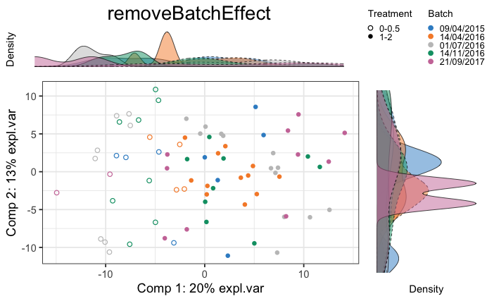

```r
ad.pca.rBE.plot <- Scatter_Density(components = ad.pca.rBE$variates$X,
                                   comp = c(1, 2),
                                   expl.var = ad.pca.rBE$prop_expl_var$X,
                                   batch = ad.batch,
                                   trt = ad.trt,
                                   title = 'removeBatchEffect',
                                   color.set = color.mixo(1:5))
```

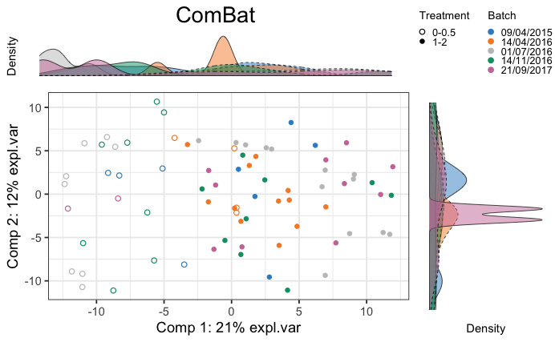

```r
ad.pca.ComBat.plot <- Scatter_Density(components = ad.pca.ComBat$variates$X,
                                      comp = c(1, 2),
                                      expl.var = ad.pca.ComBat$prop_expl_var$X,
                                      batch = ad.batch,
                                      trt = ad.trt,
                                      title = 'ComBat',
                                      color.set = color.mixo(1:5))
```

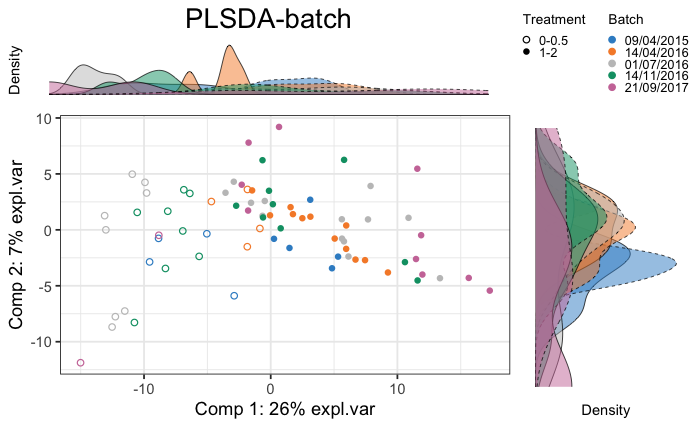

```r
ad.pca.PLSDA_batch.plot <- Scatter_Density(components = ad.pca.PLSDA_batch$variates$X,
                                           comp = c(1, 2),
                                           expl.var = ad.pca.PLSDA_batch$prop_expl_var$X,
                                           batch = ad.batch,
                                           trt = ad.trt,
                                           title = 'PLSDA-batch',
                                           color.set = color.mixo(1:5))
```

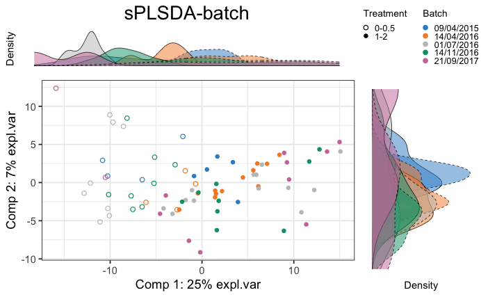

```r
ad.pca.sPLSDA_batch.plot <- Scatter_Density(components = ad.pca.sPLSDA_batch$variates$X,
                                            comp = c(1, 2),
                                            expl.var = ad.pca.sPLSDA_batch$prop_expl_var$X,
                                            batch = ad.batch,
                                            trt = ad.trt,
                                            title = 'sPLSDA-batch',
                                            color.set = color.mixo(1:5))
```

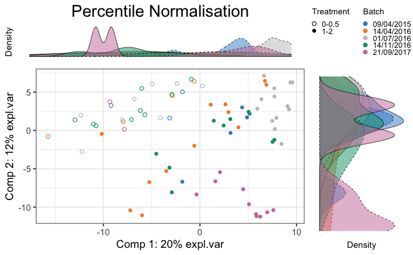

```r
ad.pca.PN.plot <- Scatter_Density(components = ad.pca.PN$variates$X,
                                  comp = c(1, 2),
                                  expl.var = ad.pca.PN$prop_expl_var$X,
                                  batch = ad.batch,
                                  trt = ad.trt,
                                  title = 'Percentile Normalisation',
                                  color.set = color.mixo(1:5))
```

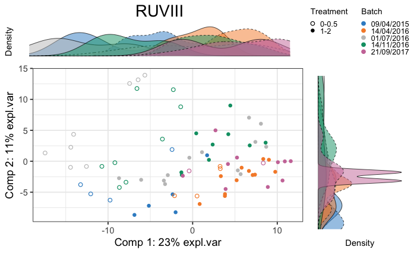

```r
ad.pca.RUVIII.plot <- Scatter_Density(components = ad.pca.RUVIII$variates$X,
                                      comp = c(1, 2),
                                      expl.var = ad.pca.RUVIII$prop_expl_var$X,
                                      batch = ad.batch,
                                      trt = ad.trt,
                                      title = 'RUVIII',
                                      color.set = color.mixo(1:5))
```

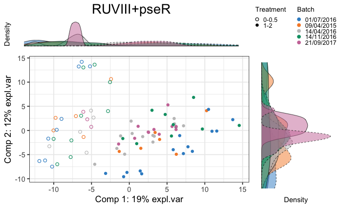

```r
ad.pca.RUVIII.new.plot <- Scatter_Density(components = ad.pca.RUVIII.new$variates$X,
                                          comp = c(1, 2),
                                          expl.var = ad.pca.RUVIII.new$prop_expl_var$X,
                                          batch = ad.batch.new,
                                          trt = ad.trt.new,
                                          title = 'RUVIII+pseR',
                                          color.set = color.mixo(1:5))
```

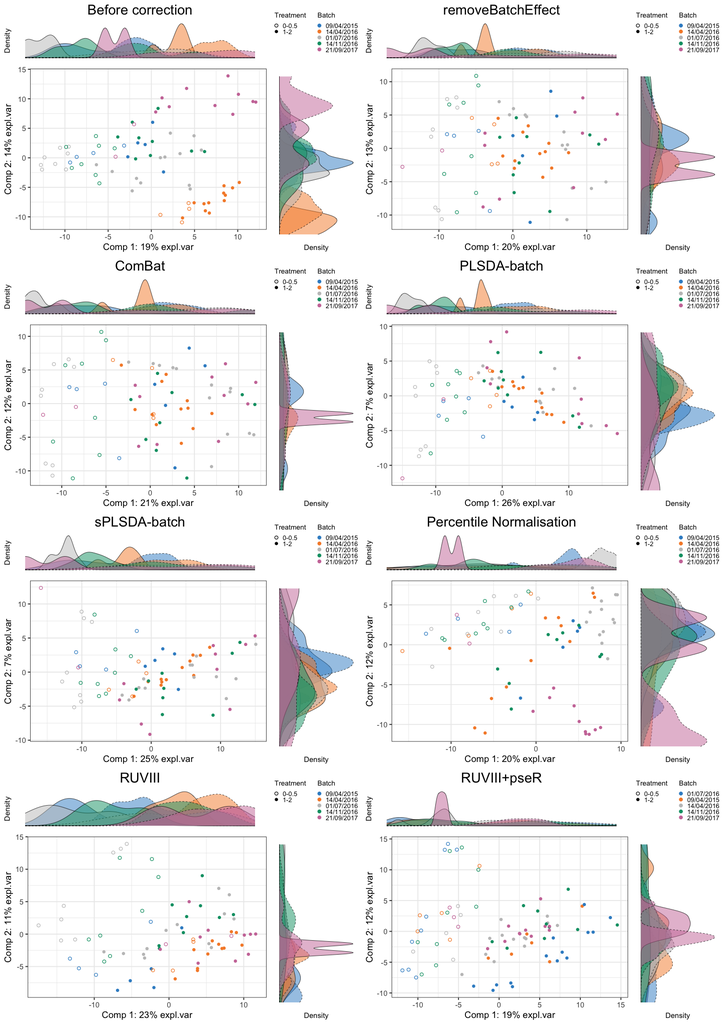

### pRDA

We can also calculate and display the pRDA results for the data before and after batch effect correction using all methods presented in the workshop.

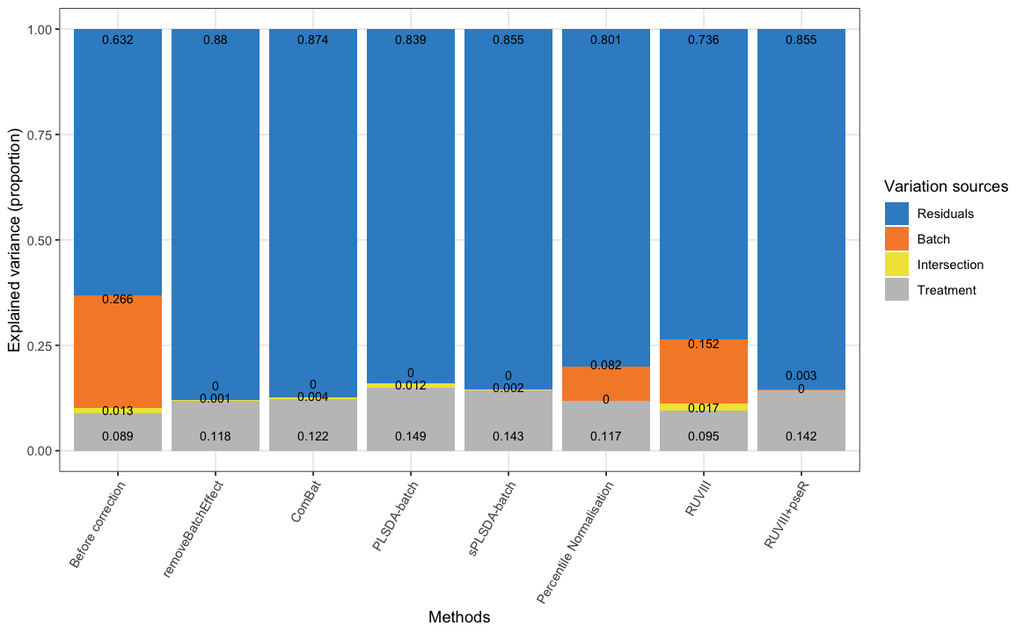

```r
ad.corrected.list <- list(`Before correction` = ad.clr,
                          removeBatchEffect = ad.rBE,
                          ComBat = ad.ComBat,
                          `PLSDA-batch` = ad.PLSDA_batch,
                          `sPLSDA-batch` = ad.sPLSDA_batch,
                          `Percentile Normalisation` = ad.PN,
                          RUVIII = ad.RUVIII)

ad.prop.df <- data.frame(Treatment = NA, Batch = NA,
                         Intersection = NA,
                         Residuals = NA)
for(i in seq_len(length(ad.corrected.list))){
  rda.res = varpart(ad.corrected.list[[i]], ~ trt, ~ batch,
                    data = ad.factors.df, scale = TRUE)
  ad.prop.df[i, ] <- rda.res$part$indfract$Adj.R.squared}

rownames(ad.prop.df) = names(ad.corrected.list)

ad.prop.df <- ad.prop.df[, c(1,3,2,4)]

ad.prop.df[ad.prop.df < 0] = 0
ad.prop.df <- as.data.frame(t(apply(ad.prop.df, 1,
                                    function(x){x/sum(x)})))

# RUVIII + pseudo replicates
rda.ruviii = varpart(ad.RUVIII.new, ~ ad.trt.new, ~ ad.batch.new, scale = TRUE)
RUVIII.prop = rda.ruviii$part$indfract$Adj.R.squared[c(1,3,2,4)]

RUVIII.prop[RUVIII.prop < 0] = 0
RUVIII.prop <- RUVIII.prop/sum(RUVIII.prop)

ad.prop.df <- rbind(ad.prop.df, `RUVIII+pseR` = RUVIII.prop)

partVar_plot(prop.df = ad.prop.df, color.set = color.mixo(c(3,6,2,1)))
```

We can also apply additional methods introduced in the workshop to evaluate batch effect correction.

# References

Chapleur, Olivier, Céline Madigou, Raphaël Civade, Yohan Rodolphe, Laurent Mazéas, and Théodore Bouchez. 2016. “Increasing Concentrations of Phenol Progressively Affect Anaerobic Digestion of Cellulose and Associated Microbial Communities.” *Biodegradation* 27 (1): 15–27.

LÃŒdecke, Daniel, Dominique Makowski, Philip Waggoner, and Indrajeet Patil. 2020. “Performance: Assessment of Regression Models Performance.” *CRAN*, ahead of print. https://doi.org/10.5281/zenodo.3952174.

Leek, Jeffrey T, W Evan Johnson, Hilary S Parker, Andrew E Jaffe, and John D Storey. 2012. “The Sva Package for Removing Batch Effects and Other Unwanted Variation in High-Throughput Experiments.” *Bioinformatics* 28 (6): 882–83.

Moskovicz, Veronica, Rina Ben-El, Guy Horev, and Boaz Mizrahi. 2020. *Skin Microbiota Dynamics Following b. Subtilis Formulation Challenge*.

Rohart, Florian, Benoı̂t Gautier, Amrit Singh, and Kim-Anh Lê Cao. 2017. “mixOmics: An r Package for ‘Omics Feature Selection and Multiple Data Integration.” *PLoS Computational Biology* 13 (11): e1005752.

Wang, Yiwen, and Kim-Anh Lê Cao. 2023. “PLSDA-Batch: A Multivariate Framework to Correct for Batch Effects in Microbiome Data.” *Briefings in Bioinformatics* 24 (2): bbac622.

Wang, Yiwen, and Kim-Anh LêCao. 2020. “Managing Batch Effects in Microbiome Data.” *Briefings in Bioinformatics* 21 (6): 1954–70.